# Time Series HW8

Yaniv Bronshtein(yb262)

11/30/2021

**Import the necessary libraries**

```r
library(sarima)
library(forecast)
```

3. For the following models, simulate 400 observations, estimate the model, obtain 1-step ahead to 12-step ahead predictions and their standard errors, and plot the last 24 observed observations with the predictions and their 95% confidence intervals.
1. $(x_t−20)=−0.7(x_{t−1}−20)+\epsilon_t,\epsilon_t ∼ N(0,5^2)$

```r
set.seed(123)
sim1 <- arima.sim(model=list(order=c(1,0,0), ar=c(-0.7)), n=400, sd = 5)+20
model1 <- arima(sim1, order=c(1,0,0))
model1.pred <- predict(model1, n.ahead=12)
```

**Predictions for model 1**

```r
model1.pred$pred
```

```
## Time Series:
## Start = 401
## End = 412
## Frequency = 1
##  [1] 22.61501 18.21987 21.20547 19.17736 20.55505 19.61919 20.25492 19.82307
##  [9] 20.11642 19.91715 20.05251 19.96056
```

**Standard errors for model 1 predictions**

```r
model1.pred$se
```

```
## Time Series:
## Start = 401
## End = 412
## Frequency = 1
##  [1] 4.821014 5.828133 6.238277 6.418704 6.500273 6.537569 6.554708 6.562601
##  [9] 6.566240 6.567919 6.568693 6.569051
```

**Plot last 24 observations with 95% confidence intervals for predictions**

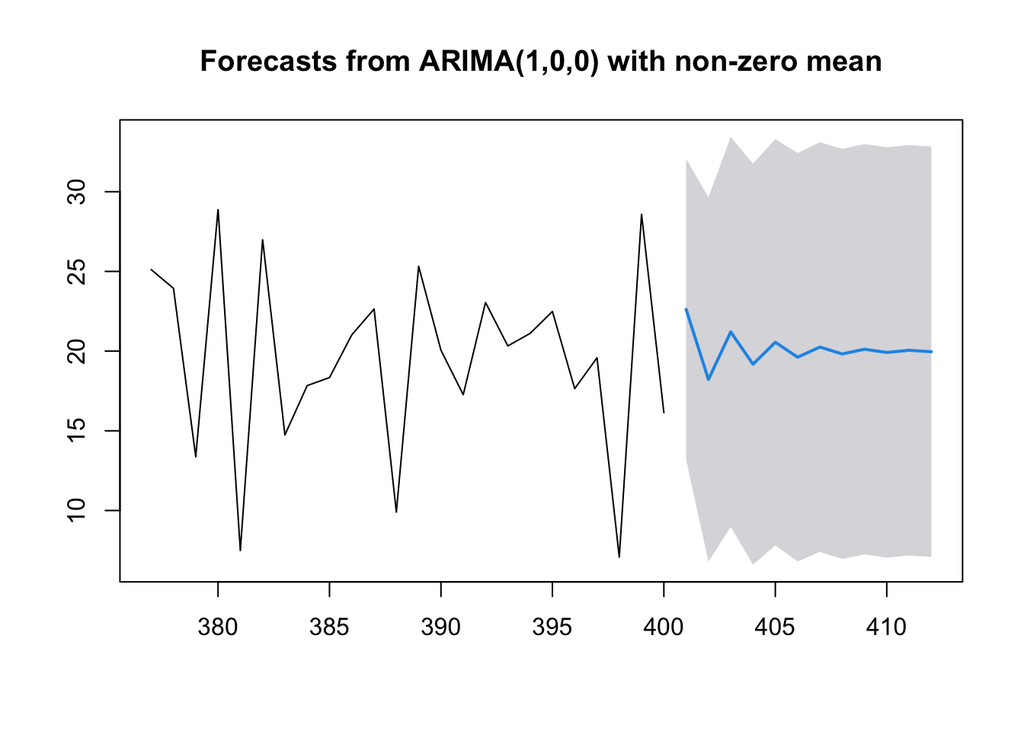

```r
plot(forecast(model1,h=12, level=0.95), include=24)
```

2. $(1−1.4B+0.48B^2)(x_t−20)=(1+1.2B+0.35B^2)\epsilon_t,\epsilon_t ∼N(0,5^2)$

```r
set.seed(123)
sim2 <- arima.sim(model=list(order=c(2,0,2),ar=c(1.4,-0.48), ma=c(1.2,0.35)), n=400, sd=5)+20
model2 <- arima(sim2, order=c(2,0,2))
model2.pred <- predict(model2, n.ahead=12)
```

**Model 2 predictions**

```r
model2.pred$pred
```

```
## Time Series:
## Start = 401
## End = 412
## Frequency = 1
##  [1] 65.05035 54.46571 45.90735 39.25102 34.23000 30.53848 27.88528 26.01794
##  [9] 24.73006 23.85973 23.28400 22.91196
```

**Standard errors for model 2 predictions**

```r
model2.pred$se
```

```
## Time Series:
## Start = 401
## End = 412
## Frequency = 1
##  [1]  4.82509 13.17455 20.63327 26.03732 29.63439 31.89041 33.23671 34.00483
##  [9] 34.42500 34.64576 34.75729 34.81150
```

**Plot last 24 observations with 95% confidence intervals for predictions**

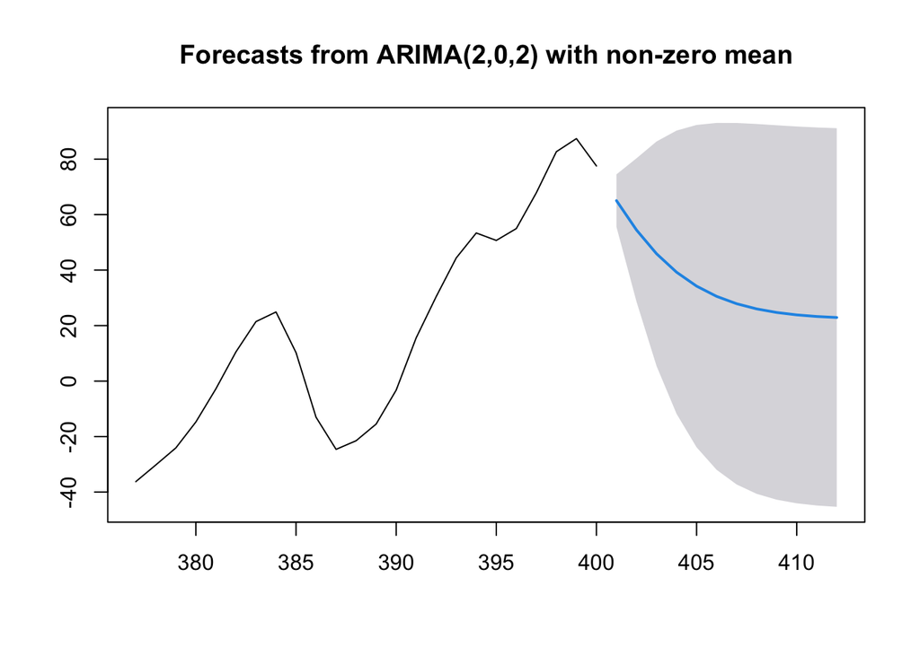

```r
plot(forecast(model2,h=12, level=0.95), include=24)
```

3. $(1−0.8B)\Delta x_t = (1+0.6B)\epsilon_t,\epsilon_t ∼ N(0,5^2)$

```r
set.seed(123)
sim3 <- arima.sim(model=list(order=c(1,1,1),ar=c(0.8), ma=c(0.6)), n=400, sd=5)
model3 <- arima(sim3, order=c(1,1,1))
model3.pred <- predict(model3, n.ahead=12)
```

**Model 3 predictions**

```r
model3.pred$pred
```

```
## Time Series:
## Start = 402
## End = 413
## Frequency = 1
##  [1] 283.0256 299.3452 311.1959 319.8014 326.0503 330.5881 333.8833 336.2761
##  [9] 338.0136 339.2754 340.1916 340.8570
```

**Standard errors for model 3 predictions**

```r
model3.pred$se
```

```
## Time Series:
## Start = 402
## End = 413
## Frequency = 1
##  [1]  4.837976 12.392390 20.380972 28.307836 35.951017 43.219673 50.088131
##  [8] 56.563335 62.667865 68.430860 73.883155 79.054761
```

**Plot last 24 observations with 95% confidence intervals for predictions**

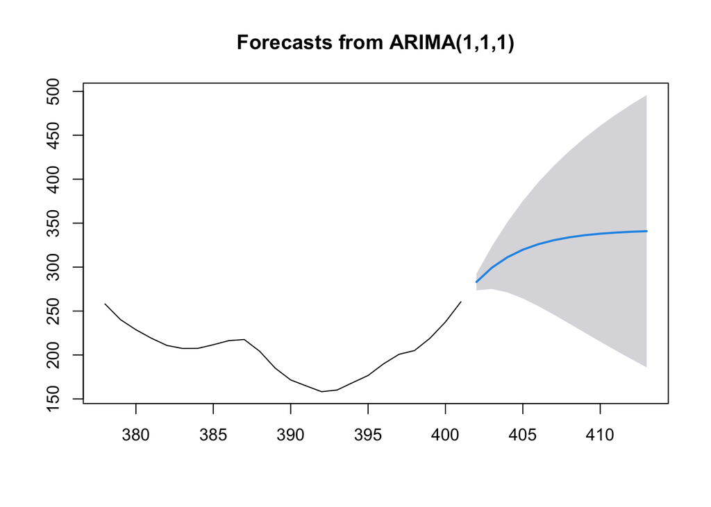

```r
plot(forecast(model3,h=12, level=0.95), include=24)
```

4. $(1−B^{12})x_t =(1+0.8B)(1+0.8B^{12})\epsilon_t,\epsilon_t ∼N(0,5^2)$.

$ARIMA(0,0,1)(1,0,1)_{12}$

```r
set.seed(123)
sim4 <- sim_sarima(model=list(siorder=1, ma=c(0.8), sma=c(0.8), nseasons=12), n=400, sd=5)

model4 <- arima(sim4, order=c(0,0,1), seasonal=list(order=c(1,0,1), period=12))

model4.pred <- predict(model4, n.ahead=12)
```

**Model 4 predictions**

```r
model4.pred$pred
```

```
## Time Series:
## Start = 401
## End = 412
## Frequency = 1
##  [1] -3.3739258  5.7240993 18.3386909  4.5111090  7.2202443 10.6474639
##  [7] -1.0901893 -7.5589013 -9.5697695 -3.6018103  0.5235469 -4.4363520
```

**Standard errors for model 4 predictions**

```r
model4.pred$se
```

```
## Time Series:
## Start = 401
## End = 412
## Frequency = 1
##  [1] 0.944145 1.219792 1.219792 1.219792 1.219792 1.219792 1.219792 1.219792
##  [9] 1.219792 1.219792 1.219792 1.219792
```

**Plot last 24 observations with 95% confidence intervals for predictions**

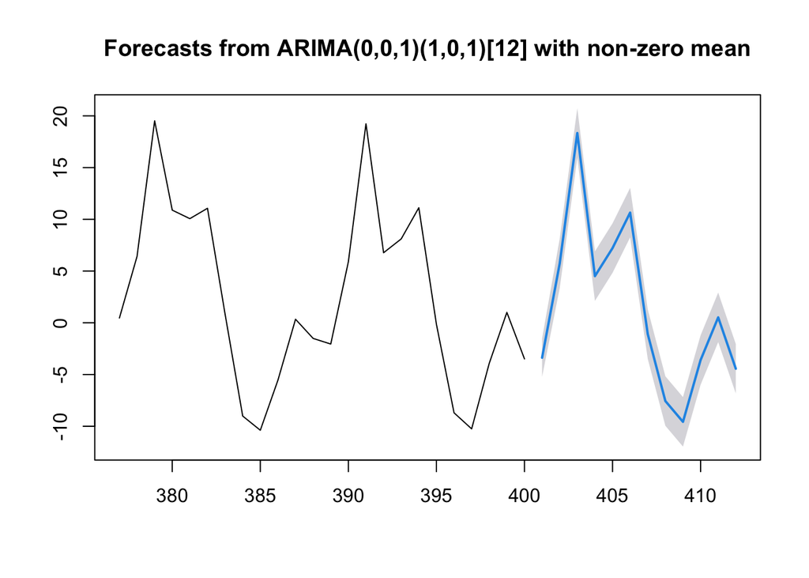

```r
plot(forecast(model4,h=12, level=0.95), include=24)
```